# Propser Loan Data Analysis

## Introduction

The Prosper loan dataset contains 113,937 loans with 81 variables on each loan, including loan amount, borrower rate, current loan status, borrower income, and others.

## Preliminary Wrangling

```python
# import all packages and set plots to be embedded inline
import numpy as np
import pandas as pd
import matplotlib.pyplot as plt
import seaborn as sb

%matplotlib inline
# suppress warnings from final output
import warnings
warnings.simplefilter("ignore")
```

Load in your dataset and describe its properties through the questions below. Try and motivate your exploration goals through this section.

```python
#Load the loan data from local storage.
df_loan = pd.read_csv('prosperLoanData.csv')
```

```python
#Display sample data
df_loan.sample(5)
```

|  | ListingKey | ListingNumber | ListingCreationDate | CreditGrade | Term | LoanStatus | ClosedDate | BorrowerAPR | BorrowerRate | LenderYield | ... | LP_ServiceFees | LP_CollectionFees | LP_GrossPrincipalLoss | LP_NetPrincipalLoss | LP_NonPrincipalRecoverypayments | PercentFunded | Recommendations | InvestmentFromFriendsCount | InvestmentFromFriendsAmount | Investors |
| --- | --- | --- | --- | --- | --- | --- | --- | --- | --- | --- | --- | --- | --- | --- | --- | --- | --- | --- | --- | --- | --- |
| 34427 | B25F3559675417031DF5F88 | 644408 | 2012-09-24 13:29:08.880000000 | NaN | 36 | Completed | 2013-05-03 00:00:00 | 0.24758 | 0.2099 | 0.1999 | ... | -116.99 | 0.0 | 0.0 | 0.0 | 0.0 | 1.0 | 0 | 0 | 0.0 | 22 |
| 47384 | 929835939664446297255B3 | 968278 | 2013-11-01 09:31:58.710000000 | NaN | 60 | Current | NaN | 0.24036 | 0.2155 | 0.2055 | ... | -24.96 | 0.0 | 0.0 | 0.0 | 0.0 | 1.0 | 0 | 0 | 0.0 | 1 |
| 75729 | 4BBE3595128479276C5BD81 | 1010006 | 2013-11-11 09:25:12.330000000 | NaN | 36 | Current | NaN | 0.15324 | 0.1249 | 0.1149 | ... | -61.54 | 0.0 | 0.0 | 0.0 | 0.0 | 1.0 | 0 | 0 | 0.0 | 1 |
| 29369 | A1883542648820723B57082 | 572779 | 2012-03-27 14:45:30.530000000 | NaN | 12 | Completed | 2013-04-03 00:00:00 | 0.13706 | 0.0609 | 0.0509 | ... | -16.46 | 0.0 | 0.0 | 0.0 | 0.0 | 1.0 | 0 | 0 | 0.0 | 31 |
| 106956 | D8D935869978352199BA240 | 877244 | 2013-08-22 15:18:19.223000000 | NaN | 36 | Current | NaN | 0.21945 | 0.1824 | 0.1724 | ... | -16.73 | 0.0 | 0.0 | 0.0 | 0.0 | 1.0 | 0 | 0 | 0.0 | 1 |

5 rows × 81 columns

```python
# Overview of data shape and composition
df_loan.shape
```

```
(113937, 81)
```

```python
# Verify the structure of the dataset
df_loan.info()
```

```
<class 'pandas.core.frame.DataFrame'>
RangeIndex: 113937 entries, 0 to 113936
Data columns (total 81 columns):
ListingKey                             113937 non-null object
ListingNumber                          113937 non-null int64
ListingCreationDate                    113937 non-null object
CreditGrade                            28953 non-null object
Term                                   113937 non-null int64
LoanStatus                             113937 non-null object
ClosedDate                             55089 non-null object
BorrowerAPR                            113912 non-null float64
BorrowerRate                           113937 non-null float64
LenderYield                            113937 non-null float64
EstimatedEffectiveYield                84853 non-null float64
EstimatedLoss                          84853 non-null float64
EstimatedReturn                        84853 non-null float64
ProsperRating (numeric)                84853 non-null float64
ProsperRating (Alpha)                  84853 non-null object
ProsperScore                           84853 non-null float64
ListingCategory (numeric)              113937 non-null int64
BorrowerState                          108422 non-null object
Occupation                             110349 non-null object
EmploymentStatus                       111682 non-null object
EmploymentStatusDuration               106312 non-null float64
IsBorrowerHomeowner                    113937 non-null bool
CurrentlyInGroup                       113937 non-null bool
GroupKey                               13341 non-null object
DateCreditPulled                       113937 non-null object
CreditScoreRangeLower                  113346 non-null float64
CreditScoreRangeUpper                  113346 non-null float64
FirstRecordedCreditLine                113240 non-null object
CurrentCreditLines                     106333 non-null float64
OpenCreditLines                        106333 non-null float64
TotalCreditLinespast7years             113240 non-null float64
OpenRevolvingAccounts                  113937 non-null int64
OpenRevolvingMonthlyPayment            113937 non-null float64
InquiriesLast6Months                   113240 non-null float64
TotalInquiries                         112778 non-null float64
CurrentDelinquencies                   113240 non-null float64
AmountDelinquent                       106315 non-null float64
```

[output cut: 31 more lines]

```
LP_CustomerPayments                    113937 non-null float64
LP_CustomerPrincipalPayments           113937 non-null float64
LP_InterestandFees                     113937 non-null float64
LP_ServiceFees                         113937 non-null float64
LP_CollectionFees                      113937 non-null float64
LP_GrossPrincipalLoss                  113937 non-null float64
LP_NetPrincipalLoss                    113937 non-null float64
LP_NonPrincipalRecoverypayments        113937 non-null float64
PercentFunded                          113937 non-null float64
Recommendations                        113937 non-null int64
InvestmentFromFriendsCount             113937 non-null int64
InvestmentFromFriendsAmount            113937 non-null float64
Investors                              113937 non-null int64
dtypes: bool(3), float64(50), int64(11), object(17)
memory usage: 68.1+ MB
```

```python
df_loan.columns
```

```
Index(['ListingKey', 'ListingNumber', 'ListingCreationDate', 'CreditGrade',
       'Term', 'LoanStatus', 'ClosedDate', 'BorrowerAPR', 'BorrowerRate',
       'LenderYield', 'EstimatedEffectiveYield', 'EstimatedLoss',
       'EstimatedReturn', 'ProsperRating (numeric)', 'ProsperRating (Alpha)',
       'ProsperScore', 'ListingCategory (numeric)', 'BorrowerState',
       'Occupation', 'EmploymentStatus', 'EmploymentStatusDuration',
       'IsBorrowerHomeowner', 'CurrentlyInGroup', 'GroupKey',
       'DateCreditPulled', 'CreditScoreRangeLower', 'CreditScoreRangeUpper',
       'FirstRecordedCreditLine', 'CurrentCreditLines', 'OpenCreditLines',
       'TotalCreditLinespast7years', 'OpenRevolvingAccounts',
       'OpenRevolvingMonthlyPayment', 'InquiriesLast6Months', 'TotalInquiries',
       'CurrentDelinquencies', 'AmountDelinquent', 'DelinquenciesLast7Years',
       'PublicRecordsLast10Years', 'PublicRecordsLast12Months',
       'RevolvingCreditBalance', 'BankcardUtilization',
       'AvailableBankcardCredit', 'TotalTrades',
       'TradesNeverDelinquent (percentage)', 'TradesOpenedLast6Months',
       'DebtToIncomeRatio', 'IncomeRange', 'IncomeVerifiable',
       'StatedMonthlyIncome', 'LoanKey', 'TotalProsperLoans',
       'TotalProsperPaymentsBilled', 'OnTimeProsperPayments',
       'ProsperPaymentsLessThanOneMonthLate',
       'ProsperPaymentsOneMonthPlusLate', 'ProsperPrincipalBorrowed',
       'ProsperPrincipalOutstanding', 'ScorexChangeAtTimeOfListing',
       'LoanCurrentDaysDelinquent', 'LoanFirstDefaultedCycleNumber',
       'LoanMonthsSinceOrigination', 'LoanNumber', 'LoanOriginalAmount',
       'LoanOriginationDate', 'LoanOriginationQuarter', 'MemberKey',
       'MonthlyLoanPayment', 'LP_CustomerPayments',
       'LP_CustomerPrincipalPayments', 'LP_InterestandFees', 'LP_ServiceFees',
       'LP_CollectionFees', 'LP_GrossPrincipalLoss', 'LP_NetPrincipalLoss',
       'LP_NonPrincipalRecoverypayments', 'PercentFunded', 'Recommendations',
       'InvestmentFromFriendsCount', 'InvestmentFromFriendsAmount',
       'Investors'],
      dtype='object')
```

```python
# convert to datetime
df_loan['LoanOriginationDate'] = pd.to_datetime(df_loan['LoanOriginationDate'])
```

```python
#test
result = df_loan['LoanOriginationDate'].dtypes
print("output:")
print(result)
```

```
output:
datetime64[ns]
```

```python
# replace null by the mean value
debt_means = df_loan['DebtToIncomeRatio'].mean()
creditlower_means = df_loan['CreditScoreRangeLower'].mean()
emp_stat_dur_means = df_loan['EmploymentStatusDuration'].mean()

df_loan['DebtToIncomeRatio'] = df_loan['DebtToIncomeRatio'].fillna(debt_means)
df_loan['CreditScoreRangeLower'] = df_loan['CreditScoreRangeLower'].fillna(creditlower_means)
df_loan['EmploymentStatusDuration'] = df_loan['EmploymentStatusDuration'].fillna(emp_stat_dur_means)
```

```python
#generate the statistics of the dataset
df_loan.describe()
```

|  | ListingNumber | Term | BorrowerAPR | BorrowerRate | LenderYield | EstimatedEffectiveYield | EstimatedLoss | EstimatedReturn | ProsperRating (numeric) | ProsperScore | ... | LP_ServiceFees | LP_CollectionFees | LP_GrossPrincipalLoss | LP_NetPrincipalLoss | LP_NonPrincipalRecoverypayments | PercentFunded | Recommendations | InvestmentFromFriendsCount | InvestmentFromFriendsAmount | Investors |
| --- | --- | --- | --- | --- | --- | --- | --- | --- | --- | --- | --- | --- | --- | --- | --- | --- | --- | --- | --- | --- | --- |
| count | 1.139370e+05 | 113937.000000 | 113912.000000 | 113937.000000 | 113937.000000 | 84853.000000 | 84853.000000 | 84853.000000 | 84853.000000 | 84853.000000 | ... | 113937.000000 | 113937.000000 | 113937.000000 | 113937.000000 | 113937.000000 | 113937.000000 | 113937.000000 | 113937.000000 | 113937.000000 | 113937.000000 |
| mean | 6.278857e+05 | 40.830248 | 0.218828 | 0.192764 | 0.182701 | 0.168661 | 0.080306 | 0.096068 | 4.072243 | 5.950067 | ... | -54.725641 | -14.242698 | 700.446342 | 681.420499 | 25.142686 | 0.998584 | 0.048027 | 0.023460 | 16.550751 | 80.475228 |
| std | 3.280762e+05 | 10.436212 | 0.080364 | 0.074818 | 0.074516 | 0.068467 | 0.046764 | 0.030403 | 1.673227 | 2.376501 | ... | 60.675425 | 109.232758 | 2388.513831 | 2357.167068 | 275.657937 | 0.017919 | 0.332353 | 0.232412 | 294.545422 | 103.239020 |
| min | 4.000000e+00 | 12.000000 | 0.006530 | 0.000000 | -0.010000 | -0.182700 | 0.004900 | -0.182700 | 1.000000 | 1.000000 | ... | -664.870000 | -9274.750000 | -94.200000 | -954.550000 | 0.000000 | 0.700000 | 0.000000 | 0.000000 | 0.000000 | 1.000000 |
| 25% | 4.009190e+05 | 36.000000 | 0.156290 | 0.134000 | 0.124200 | 0.115670 | 0.042400 | 0.074080 | 3.000000 | 4.000000 | ... | -73.180000 | 0.000000 | 0.000000 | 0.000000 | 0.000000 | 1.000000 | 0.000000 | 0.000000 | 0.000000 | 2.000000 |
| 50% | 6.005540e+05 | 36.000000 | 0.209760 | 0.184000 | 0.173000 | 0.161500 | 0.072400 | 0.091700 | 4.000000 | 6.000000 | ... | -34.440000 | 0.000000 | 0.000000 | 0.000000 | 0.000000 | 1.000000 | 0.000000 | 0.000000 | 0.000000 | 44.000000 |
| 75% | 8.926340e+05 | 36.000000 | 0.283810 | 0.250000 | 0.240000 | 0.224300 | 0.112000 | 0.116600 | 5.000000 | 8.000000 | ... | -13.920000 | 0.000000 | 0.000000 | 0.000000 | 0.000000 | 1.000000 | 0.000000 | 0.000000 | 0.000000 | 115.000000 |
| max | 1.255725e+06 | 60.000000 | 0.512290 | 0.497500 | 0.492500 | 0.319900 | 0.366000 | 0.283700 | 7.000000 | 11.000000 | ... | 32.060000 | 0.000000 | 25000.000000 | 25000.000000 | 21117.900000 | 1.012500 | 39.000000 | 33.000000 | 25000.000000 | 1189.000000 |

8 rows × 61 columns

### What is the structure of your dataset?

The dataset has 113937 observations of 81 variables. Data types including ‘float’, ‘int’, 'bool' and ‘object’. Variables are about loan information and borrower information.

### What is/are the main feature(s) of interest in your dataset?

Features for loan and borrower.

```
 I. Borrowers
      1. Credit score
      2. Debt to income ratio
      3. Income

 II. Loans
      1. Loan amount
      2. Interest rate
      3. Term
```

### What features in the dataset do you think will help support your investigation into your feature(s) of interest?

To determine how the loans used and know what loans are delinquent, current, defaulted I used Loan Category and Loan Status.

## Univariate Exploration

```python
# splitter function
def splitString(string):
    ''' split a string, adding a space before an uppercase latter '''
    return ''.join([x if x.islower() else f" {x}" for x in string])
```

```python
# function to plot histogram
def myHistPlot(df, x_var, interval, figsize = [14,6], title = ''):
    """ Function to create histogram plot """

    #set intervals for bin
    bins = np.arange(df[x_var].min(), df[x_var].max()+interval, interval)

    if figsize:
        #set plot dimension
        plt.figure(figsize=figsize)
    #plot
    sb.distplot(df[x_var], kde = False, bins = bins, hist_kws = dict(edgecolor = 'black'))

    x_var = splitString(x_var)

    #add title
    plt.title(f'Distribution of {x_var} {title}'.title(), fontsize = 14, weight = 'bold')
    #add x label and format it
    plt.xlabel(x_var.title(), fontsize = 10, weight = 'bold')
    #add y label and format it
    plt.ylabel(f'Count'.title(),  fontsize = 10, weight = 'bold')
```

```python
df_loan.CreditScoreRangeLower.describe()
```

```
count    113937.000000
mean        685.567731
std          66.285687
min           0.000000
25%         660.000000
50%         680.000000
75%         720.000000
max         880.000000
Name: CreditScoreRangeLower, dtype: float64
```

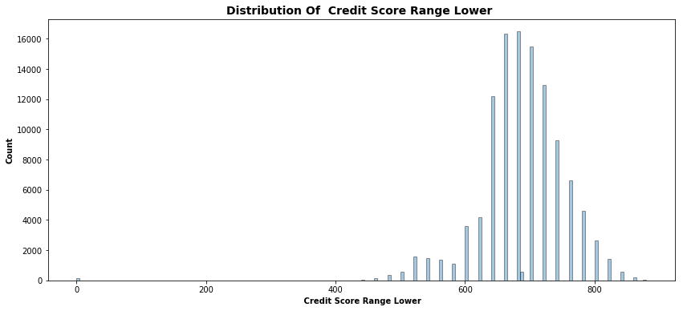

```python
myHistPlot(df_loan, 'CreditScoreRangeLower', 5)
```

As CreditScoreRangeUpper has very similar distribution but 20 points higher I just use only CreditScoreRangeLower. Credit ranges are normally distributed with mean/med = 685/680. It seem they have common intervals and are bunched as such.

```python
df_loan.DebtToIncomeRatio.describe()
```

```
count    113937.000000
mean          0.275947
std           0.530643
min           0.000000
25%           0.150000
50%           0.230000
75%           0.310000
max          10.010000
Name: DebtToIncomeRatio, dtype: float64
```

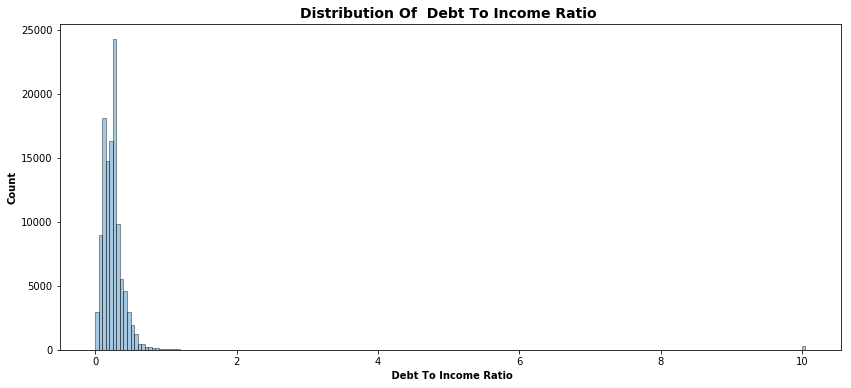

```python
# From the above we can see that the majority of the ratios fall in the range 0 : 1
myHistPlot(df_loan, 'DebtToIncomeRatio', 0.05)
```

Debit to income ratio exhibits slight positive skew mean .27 > median .23. There are more people with DI < 0.5.

```python
df_loan.StatedMonthlyIncome.describe()
```

```
count    1.139370e+05
mean     5.608026e+03
std      7.478497e+03
min      0.000000e+00
25%      3.200333e+03
50%      4.666667e+03
75%      6.825000e+03
max      1.750003e+06
Name: StatedMonthlyIncome, dtype: float64
```

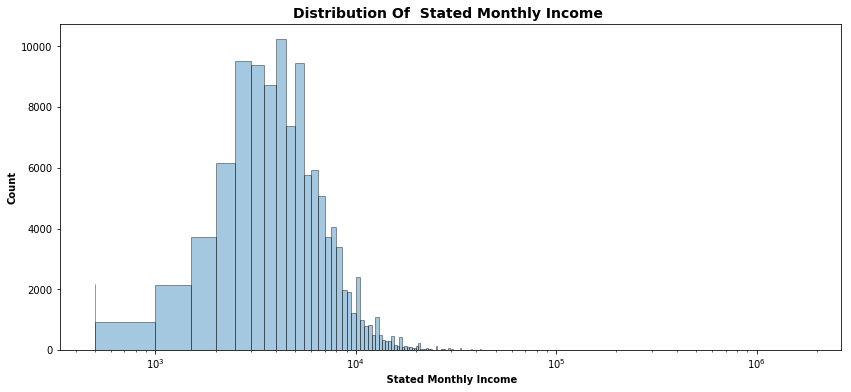

```python
myHistPlot(df_loan, 'StatedMonthlyIncome', 500)
plt.xscale('log')
```

Monthly income exhibits positive skew mean 5600 > median 4666.

The distirbution is highly skewed to the right and the monthly income of most borrowers are below 10k.

```python
df_loan.LoanOriginalAmount.describe()
```

```
count    113937.00000
mean       8337.01385
std        6245.80058
min        1000.00000
25%        4000.00000
50%        6500.00000
75%       12000.00000
max       35000.00000
Name: LoanOriginalAmount, dtype: float64
```

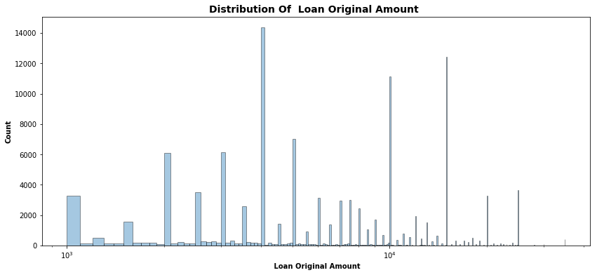

```python
myHistPlot(df_loan, 'LoanOriginalAmount', 100)
plt.xscale('log')
```

Loan amount exhibits positive skew, mean 8337 > median 6500

```python
df_loan.MonthlyLoanPayment.describe()
```

```
count    113937.000000
mean        272.475783
std         192.697812
min           0.000000
25%         131.620000
50%         217.740000
75%         371.580000
max        2251.510000
Name: MonthlyLoanPayment, dtype: float64
```

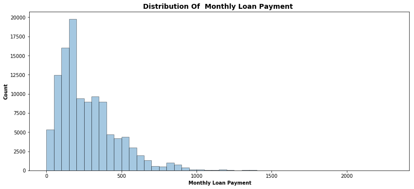

```python
myHistPlot(df_loan, 'MonthlyLoanPayment', 50)
```

MonthlyLoanPayment exhibits positive skew, mean 273 > meadian 217

```python
df_loan.BorrowerRate.describe()
```

```
count    113937.000000
mean          0.192764
std           0.074818
min           0.000000
25%           0.134000
50%           0.184000
75%           0.250000
max           0.497500
Name: BorrowerRate, dtype: float64
```

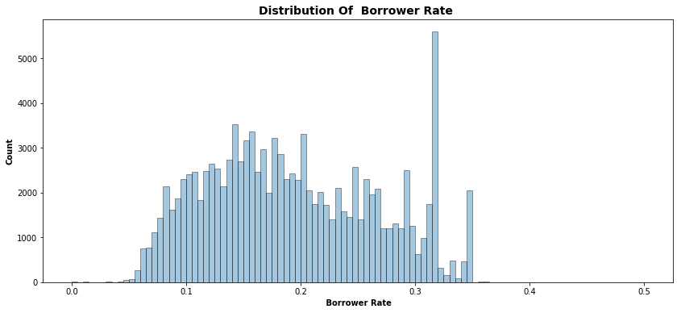

```python
myHistPlot(df_loan, 'BorrowerRate', 0.005)
```

Interest rate are normally distributed mean/meadian 0.19, and there is a spike around 0.31.

```python
df_loan.EmploymentStatusDuration.describe()
```

```
count    113937.000000
mean         96.071582
std          91.264375
min           0.000000
25%          28.000000
50%          74.000000
75%         130.000000
max         755.000000
Name: EmploymentStatusDuration, dtype: float64
```

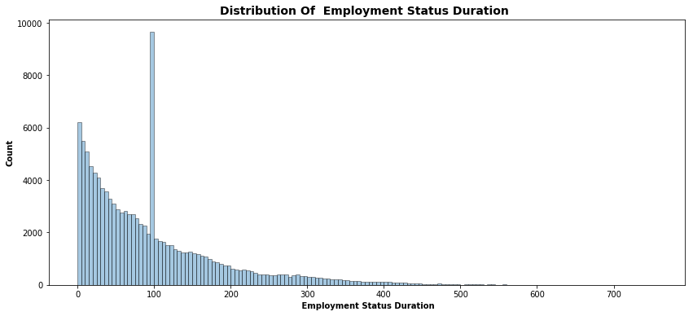

```python
myHistPlot(df_loan, 'EmploymentStatusDuration', 5)
```

From the graph we have seen that more people seems employed shorter durations and it's positive skew mean 96 > meadian 74 and some spike it might be because of null value filled with the mean value.

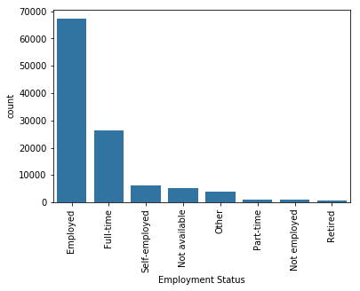

```python
# EmploymentStatus
base_color = sb.color_palette()[0]
emp_status=df_loan.EmploymentStatus.value_counts().index
sb.countplot(data=df_loan, x='EmploymentStatus', order=emp_status, color = base_color)
plt.xlabel('Employment Status')
plt.xticks(rotation=90);
```

From the above graph we have seen that majority of the borrowers are employed, which shows jobs matter to get a loan.

```python
df_curcredit = df_loan[['CurrentCreditLines']].copy()
```

```python
df_curcredit = df_curcredit.dropna()
```

```python
# test
df_curcredit['CurrentCreditLines'].isnull().values.any()
```

```
False
```

```python
df_curcredit.CurrentCreditLines.describe()
```

```
count    106333.000000
mean         10.317192
std           5.457866
min           0.000000
25%           7.000000
50%          10.000000
75%          13.000000
max          59.000000
Name: CurrentCreditLines, dtype: float64
```

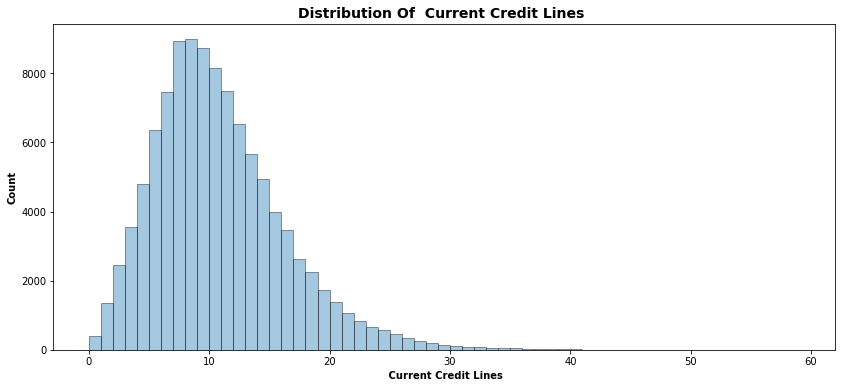

```python
myHistPlot(df_curcredit, 'CurrentCreditLines', 1)
```

from the plot we have seen that the current credit lines has a slight +ve skew with mean and median =10

```python
df_loan['LoanOriginationDate'].head(10)
```

```
0   2007-09-12
1   2014-03-03
2   2007-01-17
3   2012-11-01
4   2013-09-20
5   2013-12-24
6   2013-04-18
7   2013-05-13
8   2013-12-12
9   2013-12-12
Name: LoanOriginationDate, dtype: datetime64[ns]
```

```python
#extract year from datetime
df_loan['Year'] = df_loan['LoanOriginationDate'].dt.year
```

```python
#test
df_loan.loc[1:3, ['Year', 'LoanOriginationDate']]
```

|  | Year | LoanOriginationDate |
| --- | --- | --- |
| 1 | 2014 | 2014-03-03 |
| 2 | 2007 | 2007-01-17 |
| 3 | 2012 | 2012-11-01 |

```python
df_term = df_loan[['Year','Term']].copy()
```

```python
print(df_loan['Term'].unique())
```

```
[36 60 12]
```

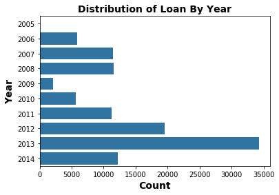

```python
base_color = sb.color_palette()[0]

# Use the `color` argument
sb.countplot(data=df_loan, y='Year', color=base_color)
plt.xlabel('Count', fontsize = 14, weight = 'bold')
plt.ylabel('Year', fontsize = 14, weight = 'bold')
plt.title(f'Distribution of Loan By Year', fontsize = 14, weight = 'bold');
```

I decomposed loan origination date and plotted by year. The loan dropped off in 2009 it's interesting.

```python
print(df_loan['Year'].unique())
```

```
[2007 2014 2012 2013 2006 2010 2011 2008 2009 2005]
```

```python
categ_order = df_loan['LoanStatus'].value_counts().index
```

```python
df_selected = df_loan.copy()
```

```python
df_selected['Year'] = df_selected['Year'].apply(str)
```

```python
df_selected['Year'].dtypes
```

```
dtype('O')
```

```python
# Convert Year to a categorical variable

year_dict = ['2005', '2006', '2007', '2008', '2009', '2010', '2011', '2012', '2013', '2014']

loan_year_order = pd.api.types.CategoricalDtype(ordered = True, categories = year_dict)

df_selected['Year'] = df_selected['Year'].astype(loan_year_order)
```

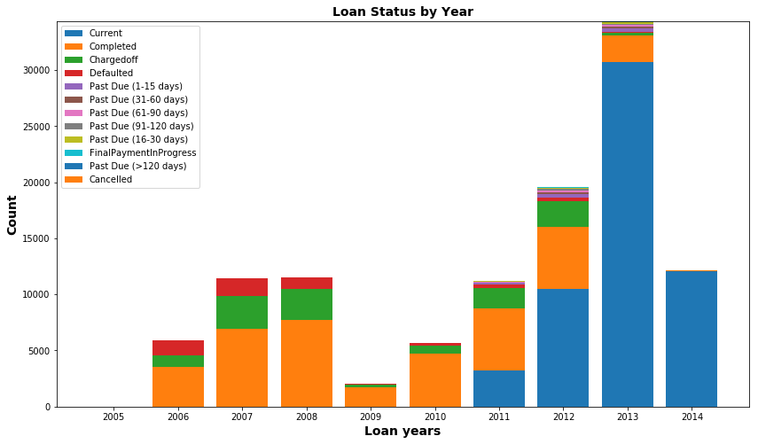

```python
baselines = np.zeros(len(year_dict))
plt.figure(figsize = [14, 8])
# for each second-variable category:
for i in range(len(categ_order)):
# isolate the counts of the first category,
    listing_cat = categ_order[i]
    inner_counts = df_selected[df_selected['LoanStatus'] == listing_cat]['Year'].value_counts()
    # then plot those counts on top of the accumulated baseline
    plt.bar(x = np.arange(len(year_dict)), height = inner_counts[year_dict],
            bottom = baselines)
    baselines += inner_counts[year_dict]

plt.xticks(np.arange(len(year_dict)), year_dict)
plt.legend(categ_order)
plt.title('Loan Status by Year', fontsize = 14, weight = 'bold')
plt.xlabel('Loan years', fontsize = 14, weight = 'bold')
plt.ylabel('Count', fontsize = 14, weight = 'bold');
```

From the above plot we have seen that most default occured in 2006-2008

### Discuss the distribution(s) of your variable(s) of interest. Were there any unusual points? Did you need to perform any transformations?

The loan original amount variable took on a large range of values, so I looked at the data using a log transform. Under the transformation, the data have some peaks on some points.

### Of the features you investigated, were there any unusual distributions? Did you perform any operations on the data to tidy, adjust, or change the form of the data? If so, why did you do this?

I broke out the loan origination date in LoanYear. This really helped with yearly analysis. And I manually set a numeric categorical variables as a factor for yearly yearly loan status.

## Bivariate Exploration

```python
# Numerical features
metric_vars = ['BorrowerRate', 'BorrowerAPR', 'DebtToIncomeRatio', 'EmploymentStatus',  'Occupation', 'ListingCategory (numeric)',
               'CurrentCreditLines','CreditScoreRangeLower', 'CreditScoreRangeLower','IsBorrowerHomeowner', 'StatedMonthlyIncome', 'LoanOriginalAmount','MonthlyLoanPayment',
               'LoanStatus','Year','LoanOriginationDate','Term','BorrowerState', 'EmploymentStatusDuration','IncomeVerifiable', 'IncomeRange']
```

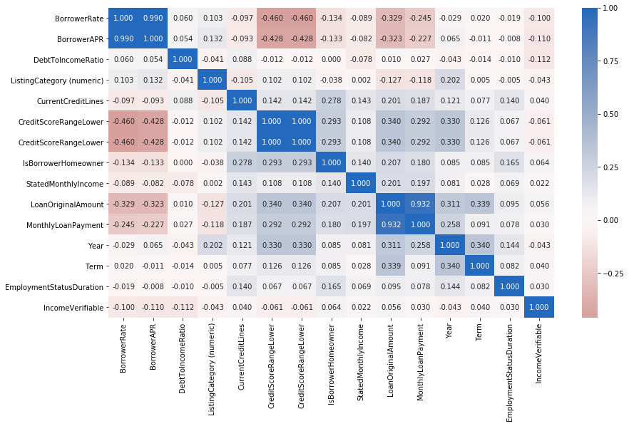

```python
# correlation plot
fig, ax = plt.subplots(figsize=(14,8))
sb.heatmap(df_loan[metric_vars].corr(), annot = True, fmt = '.3f',
           cmap = 'vlag_r', center=0)
plt.show()
```

All variables correlation matrix are discrete and continuous.

```python
def myRegPlot(df, x_var, y_var, interval, figsize = [14,6], title = ''):

    if figsize:
        #set plot dimension
        plt.figure(figsize=figsize)

    sb.regplot(data = df, x = x_var, y = y_var, scatter_kws={'alpha':interval});

    #add title
    plt.title(f'{x_var} vs {y_var}'.title(), fontsize = 14, weight = 'bold')
    #add x label and format it
    plt.xlabel(x_var.title(), fontsize = 10, weight = 'bold')
    #add y label and format it
    plt.ylabel(y_var.title(),  fontsize = 10, weight = 'bold')
```

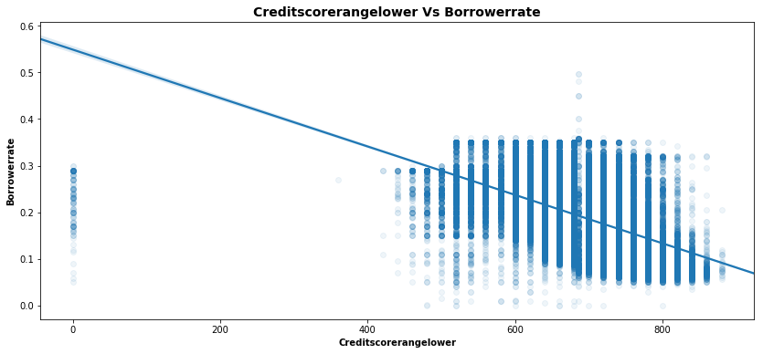

```python
myRegPlot(df_loan, 'CreditScoreRangeLower', 'BorrowerRate', 0.07)
```

They have a negative correlation, Makes sense the interest rate for more creditworthy borrowers is lower.

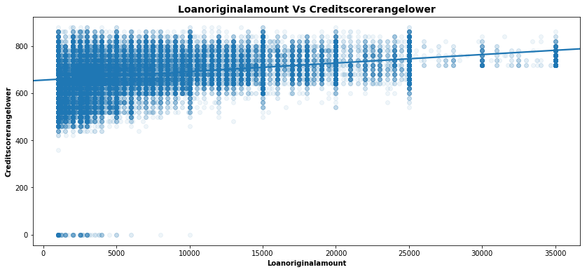

```python
myRegPlot(df_loan, 'LoanOriginalAmount', 'CreditScoreRangeLower', 0.07)
```

From the above plot we observe that the larger the loan, the higher the credit score. They are slightly positive correlated.

```
Text(0,0.5,'Loan Original Amount')
```

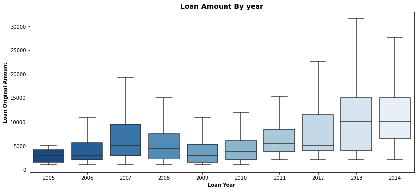

```python
# boxplots
plt.figure(figsize = [14, 6])

base_color = sb.color_palette()[0]
sb.boxplot(data = df_loan, y = 'LoanOriginalAmount', x = 'Year', palette = "Blues_r", showfliers = False)
#add title
plt.title('Loan Amount By year', fontsize = 14, weight = 'bold')
#add x label and format it
plt.xlabel('Loan Year', fontsize = 10, weight = 'bold')
#add y label and format it
plt.ylabel('Loan Original Amount',  fontsize = 10, weight = 'bold')
```

Mean loans amounts dips in 2009 and increased in 2013.

```
Text(0,0.5,'Loan Original Amount')
```

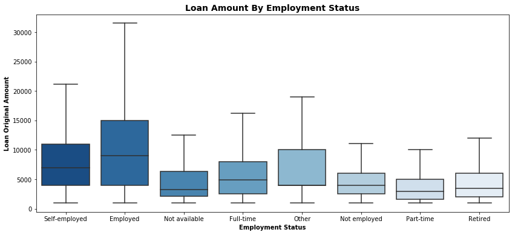

```python
# boxplots
plt.figure(figsize = [14, 6])

base_color = sb.color_palette()[0]
sb.boxplot(data = df_loan, y = 'LoanOriginalAmount', x = 'EmploymentStatus', palette = "Blues_r", showfliers = False)
#add title
plt.title('Loan Amount By Employment Status', fontsize = 14, weight = 'bold')
#add x label and format it
plt.xlabel('Employment Status', fontsize = 10, weight = 'bold')
#add y label and format it
plt.ylabel('Loan Original Amount',  fontsize = 10, weight = 'bold')
```

Employed on average take out larger loans.

```
Text(0,0.5,'Loan Original Amount')
```

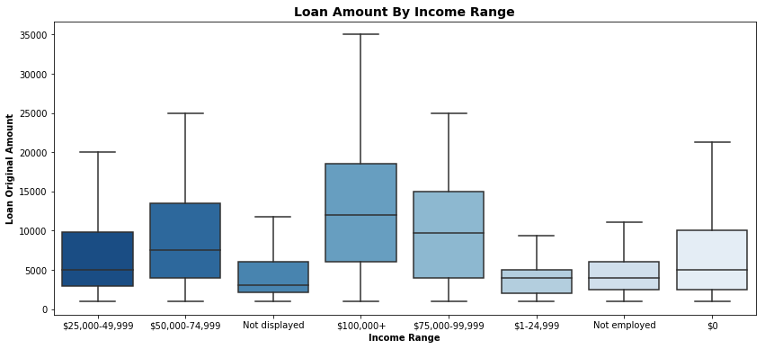

```python
# boxplots
plt.figure(figsize = [14, 6])

base_color = sb.color_palette()[0]
sb.boxplot(data = df_loan, y = 'LoanOriginalAmount', x = 'IncomeRange', palette = "Blues_r", showfliers = False)
#add title
plt.title('Loan Amount By Income Range', fontsize = 14, weight = 'bold')
#add x label and format it
plt.xlabel('Income Range', fontsize = 10, weight = 'bold')
#add y label and format it
plt.ylabel('Loan Original Amount',  fontsize = 10, weight = 'bold')
```

Larger incomes take out larger loans on average.

```
Text(0,0.5,'Loan Original Amount')
```

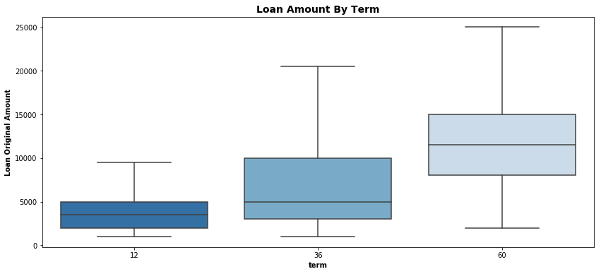

```python
# boxplots
plt.figure(figsize = [14, 6])

base_color = sb.color_palette()[0]
sb.boxplot(data = df_loan, y = 'LoanOriginalAmount', x = 'Term', palette = "Blues_r", showfliers = False)
#add title
plt.title('Loan Amount By Term', fontsize = 14, weight = 'bold')
#add x label and format it
plt.xlabel('term', fontsize = 10, weight = 'bold')
#add y label and format it
plt.ylabel('Loan Original Amount',  fontsize = 10, weight = 'bold')
```

The loan amount is larger for longer term.

```
Text(0,0.5,'Borrower Rate')
```

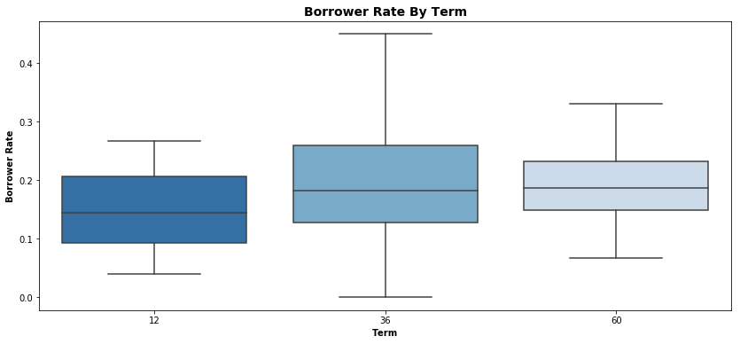

```python
# boxplots
plt.figure(figsize = [14, 6])

base_color = sb.color_palette()[0]
sb.boxplot(data = df_loan, y = 'BorrowerRate', x = 'Term', palette = "Blues_r", showfliers = False)
#add title
plt.title('Borrower Rate By Term', fontsize = 14, weight = 'bold')
#add x label and format it
plt.xlabel('Term', fontsize = 10, weight = 'bold')
#add y label and format it
plt.ylabel('Borrower Rate',  fontsize = 10, weight = 'bold')
```

The mean interest rate moves up slightly at the 5 year term and the variance is smaller.

### Talk about some of the relationships you observed in this part of the investigation. How did the feature(s) of interest vary with other features in the dataset?

- There’s a negative relationship between borrower rates and loan amount, the lower the rate on average the larger the loan. That was mostly due to them having higher credit scores.
- People who are employed on average take out larger loans than other groups.
- Longer the term, the larger the loan, there is a strong positive relationship between loan amount and term.

### Did you observe any interesting relationships between the other features (not the main feature(s) of interest)?

The strongest relationship I found was between credit score and interest rate. This makes sense since credit score is a rating of the credit-worthiness of the borrower and that should be directly related to the cost of borrowing (interest rate)

## Multivariate Exploration

```
Text(0,0.5,'Borrower Rate')
```

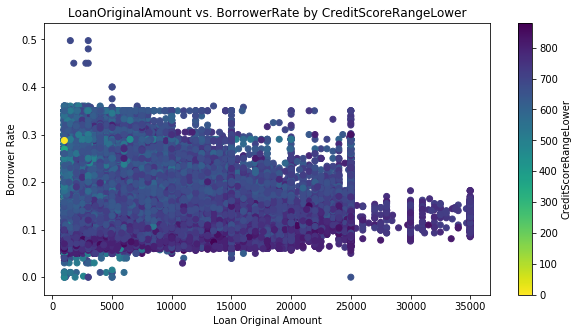

```python
plt.figure(figsize = [10, 5])
plt.scatter(data=df_loan,x='LoanOriginalAmount',y = 'BorrowerRate',c='CreditScoreRangeLower',cmap = 'viridis_r')
plt.colorbar(label = 'CreditScoreRangeLower');
plt.title('LoanOriginalAmount vs. BorrowerRate by CreditScoreRangeLower')
plt.xlabel('Loan Original Amount')
plt.ylabel('Borrower Rate')
```

The borrowers with high credit scores are on the bottom right. They generally have lower borrower rates and larger loan amounts.

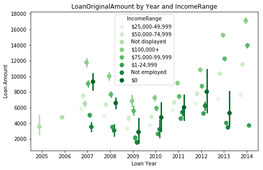

```python
fig = plt.figure(figsize = [8,5])
ax = sb.pointplot(data = df_selected, x = 'Year', y = 'LoanOriginalAmount', hue = 'IncomeRange',
           palette = 'Greens', linestyles = '', dodge = 0.5)
plt.title('LoanOriginalAmount by Year and IncomeRange')
plt.xlabel('Loan Year')
plt.ylabel('Loan Amount')
plt.show();
```

Looking at Income Ranges it looks like the uptick in loans in 2012-2013 grew primarily in $50-75k, $75-100k and $100k+.

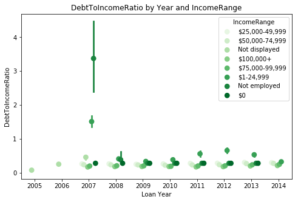

```python
fig = plt.figure(figsize = [8,5])
ax = sb.pointplot(data = df_loan, x = 'Year', y = 'DebtToIncomeRatio', hue = 'IncomeRange',
           palette = 'Greens', linestyles = '', dodge = 0.5)
plt.title('DebtToIncomeRatio by Year and IncomeRange')
plt.xlabel('Loan Year')
plt.ylabel('DebtToIncomeRatio')
plt.show();
```

Comparing DebtToIncomeRatio, most of the borrowers seem to have DebtToIncomeRatio close to 20-30% with a uptick in the most recent years. The $100k + income range have noticeably lower DebtToIncomeRatio at around 15-20%. The variance is reduced as incomes increase.

### Talk about some of the relationships you observed in this part of the investigation. Were there features that strengthened each other in terms of looking at your feature(s) of interest?

When looking at the loan amounts vs cost (interest rate), the credit scores demarcated borrowers by credit worthiness. I looked at loan amounts (normalized by credit score) vs income ranges and saw that the higher the income, the larger the loans amounts on average.

## Conclusions

Based on the above analysis the bivariate exploration revealed borrower rates and loan amount has a negative correlation, the lower the rate on average the larger the loan. That was mostly due to them having higher credit scores. People who are employed on average take out larger loans than other groups. Longer the term, the larger the loan, there is a strong positive relationship between loan amount and term.

The multivariate exploration revealed again that the higher the income, the larger the loans amounts on average.